# Will a data scientist leave your company?

According to the correlation matrix and the Gini impurity feature importance, it looks like that city_development_index is the most important feature, thus lets take a closer look at it distribution as this might influence some outlier sensitive models.

```python
df2.columns
```

```
Index(['city_development_index', 'enrolled_university', 'relevent_experience',
       'last_new_job', 'company_size', 'target'],
      dtype='object')
```

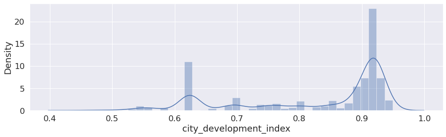

```python
    fig = plt.figure(figsize=[15,4])
    sns.distplot(df2['city_development_index'])
    plt.show()
```

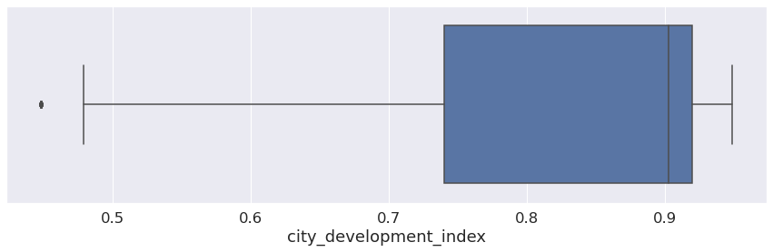

```python
    fig = plt.figure(figsize=[15,4])
    sns.boxplot(x='city_development_index', data=df2)
```

We have detected the outliers at the lower end of the city_development_index distribution. We can simply delete outliers, but that would heavily affect the model performance and we might lose some valuable information as well. I will impute outliers by shifting them to the lower_bridge of the inner quartile range of the city_development_index distribution.

```python
#calculating the Interquartile range
IQR=df2.city_development_index.quantile(0.75)-df2.city_development_index.quantile(0.25)

#calculating the borders of the normal distribution
lower_bridge=df2['city_development_index'].quantile(0.25)-(IQR*1.5)
upper_bridge=df2['city_development_index'].quantile(0.75)+(IQR*1.5)

print(round(lower_bridge,3))
print(round(upper_bridge,3))
```

```
0.47
1.19
```

```python
#Inpute the outliers with the min values that are present for the normal distribution
df2.loc[df2['city_development_index']<=lower_bridge,'city_development_index']=lower_bridge
```

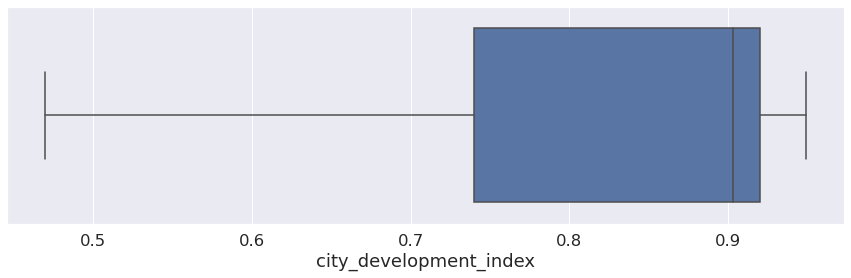

```python
    fig = plt.figure(figsize=[15,4])
    sns.boxplot(x='city_development_index', data=df2)
```

We have dealt with outliers

**Balancing dataset**

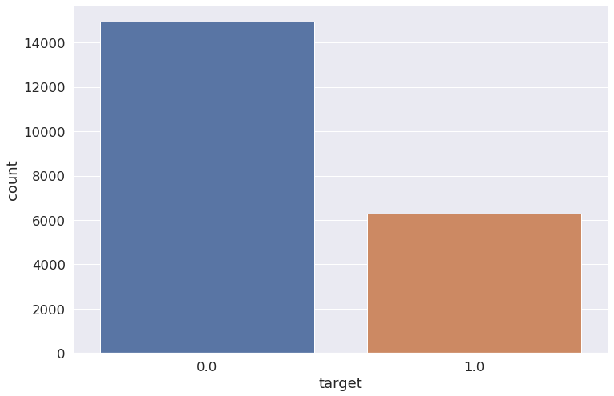

```python
# Lets take a look at the target feature
sns.countplot(data=df2, x='target')
plt.show()
```

The target feature is clearly imbalanced, thus we can use SMOTE method to randomly balance 0 and 1 values

```python
#splitting the dataset, so no information leakage occurs
X_train, X_test, y_train, y_test = train_test_split(df2.drop(labels=['target'], axis=1),
    df2['target'], test_size=0.3, random_state=0)

#using SMOTE to balance the dataset
from imblearn.over_sampling import SMOTE
from collections import Counter

os = SMOTE(random_state=0)
X_train_os,y_train_os=os.fit_sample(X_train,y_train)
X_test_os,y_test_os=os.fit_sample(X_test,y_test)
print("The number of y_train classes before fit {}".format(Counter(y_train)))
print("The number of y_train classes after fit {}".format(Counter(y_train_os)))
print("The number of y_test classes before fit {}".format(Counter(y_test)))
print("The number of y_test classes after fit {}".format(Counter(y_test_os)))
```

```
The number of y_train classes before fit Counter({0.0: 10486, 1.0: 4365})
The number of y_train classes after fit Counter({0.0: 10486, 1.0: 10486})
The number of y_test classes before fit Counter({0.0: 4456, 1.0: 1909})
The number of y_test classes after fit Counter({0.0: 4456, 1.0: 4456})
```

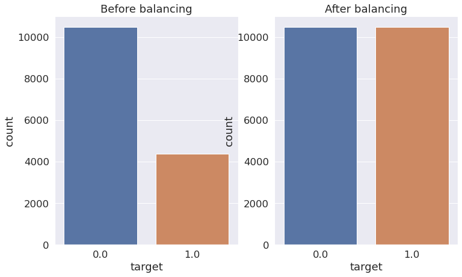

```python
fig, axes = plt.subplots(1, 2, figsize=(12, 7))

# before balancing
sns.countplot(y_train, ax=axes[0])
axes[0].set_title("Before balancing")

# after balancing
sns.countplot(y_train_os, ax=axes[1])
axes[1].set_title('After balancing')

plt.show()
```

**Scaling**

Even though some of the algorithms do not require scaling such as Tree-based models, some methods like Logistic regression or KNN do require, thus we scale our data here

```python
#feature scaling
from sklearn.preprocessing import StandardScaler
sc = StandardScaler()
X_train_scaled = sc.fit_transform(X_train_os)
X_test_scaled = sc.transform(X_test_os)
```

# Model Building

In this section we will compare the following models:

1. Logistic Regression
2. GaussianNB
3. KNeighborsClassifier
4. Decision Tree
5. Random Forest
6. Gradient Boost
7. XG Boost

```python
#Creating an estimator pipeline

estimators = {
    'Logistic Regression': [LogisticRegression()],
    'GaussianNB' :[GaussianNB()],
    'KNeighborsClassifier' :[KNeighborsClassifier()],
    'Decision Tree' :[DecisionTreeClassifier()],
    'Random Forest' :[RandomForestClassifier()],
    'Gradient Boost' :[GradientBoostingClassifier()],
    'XG Boost': [XGBClassifier()],
}


def mfit(estimators, X_train_scaled, y_train_os):
    for m in estimators:
        estimators[m][0].fit(X_train_scaled, y_train_os)
        print(m+' fitted')

mfit(estimators, X_train_scaled, y_train_os)
```

```
Logistic Regression fitted
GaussianNB fitted
KNeighborsClassifier fitted
Decision Tree fitted
Random Forest fitted
Gradient Boost fitted
[02:46:33] WARNING: ../src/learner.cc:1061: Starting in XGBoost 1.3.0, the default evaluation metric used with the objective 'binary:logistic' was changed from 'error' to 'logloss'. Explicitly set eval_metric if you'd like to restore the old behavior.
XG Boost fitted
```

Lets make predicitons

```python
def mpredict(estimators, X_test_scaled, y_test_os):
    outcome = dict()
    r_a_score = dict()
    for m in estimators:
        y_pred = estimators[m][0].predict(X_test_scaled)
        r_a_score[m] = roc_auc_score(y_test_os, y_pred)
        outcome[m] = [y_pred, confusion_matrix(y_pred,y_test_os), classification_report(y_pred,y_test_os)]
    return outcome, r_a_score

outcome, r_a_score = mpredict(estimators, X_test_scaled, y_test_os)
for m in outcome:
    print('------------------------'+m+'------------------------')
    print(outcome[m][1])
    print(outcome[m][2])
```

```
------------------------Logistic Regression------------------------
[[3140 1877]
 [1316 2579]]
              precision    recall  f1-score   support

         0.0       0.70      0.63      0.66      5017
         1.0       0.58      0.66      0.62      3895

    accuracy                           0.64      8912
   macro avg       0.64      0.64      0.64      8912
weighted avg       0.65      0.64      0.64      8912

------------------------GaussianNB------------------------
[[3169 1869]
 [1287 2587]]
              precision    recall  f1-score   support

         0.0       0.71      0.63      0.67      5038
         1.0       0.58      0.67      0.62      3874

    accuracy                           0.65      8912
   macro avg       0.65      0.65      0.64      8912
weighted avg       0.65      0.65      0.65      8912

------------------------KNeighborsClassifier------------------------
[[3186 1998]
 [1270 2458]]
              precision    recall  f1-score   support

         0.0       0.71      0.61      0.66      5184
         1.0       0.55      0.66      0.60      3728

    accuracy                           0.63      8912
   macro avg       0.63      0.64      0.63      8912
weighted avg       0.65      0.63      0.64      8912

------------------------Decision Tree------------------------
[[3441 1544]
 [1015 2912]]
              precision    recall  f1-score   support
```

[output cut: 28 more lines]

```
    accuracy                           0.73      8912
   macro avg       0.73      0.74      0.73      8912
weighted avg       0.74      0.73      0.74      8912

------------------------XG Boost------------------------
[[3595 1240]
 [ 861 3216]]
              precision    recall  f1-score   support

         0.0       0.81      0.74      0.77      4835
         1.0       0.72      0.79      0.75      4077

    accuracy                           0.76      8912
   macro avg       0.76      0.77      0.76      8912
weighted avg       0.77      0.76      0.76      8912
```

to compare the results I will apply the confusion matrix and get the scores of the variables

```python
print('roc_auc_score')
for m in r_a_score:
    print('------------------------'+m+'------------------------')
    print(r_a_score[m])
```

```
roc_auc_score
------------------------Logistic Regression------------------------
0.6417190305206464
------------------------GaussianNB------------------------
0.6458707360861758
------------------------KNeighborsClassifier------------------------
0.6333034111310593
------------------------Decision Tree------------------------
0.7128590664272891
------------------------Random Forest------------------------
0.6896319569120287
------------------------Gradient Boost------------------------
0.7346274685816876
------------------------XG Boost------------------------
0.7642504488330341
```

# Hyperparameter tuning

All Techniques Of Hyperparameter Optimization

1. GridSearchCV
2. RandomizedSearchCV
3. Bayesian Optimization -Automate Hyperparameter Tuning (Hyperopt)
4. Sequential Model Based Optimization(Tuning a scikit-learn estimator with skopt)
5. Optuna- Automate Hyperparameter Tuning
6. Genetic Algorithms (TPOT Classifier)

For thsi kernel I will use Optuna

Optuna is an open source hyperparameter optimization (HPO) framework to automate search space of hyperparameter. For finding an optimal set of hyperparameters, Optuna uses Bayesian method. It supports various types of samplers listed below :

- GridSampler (using grid search)
- RandomSampler (using random sampling)
- TPESampler (using Tree-structured Parzen Estimator algorithm)
- CmaEsSampler ( using CMA-ES algorithm)

More about Optuna you can find [here](https://medium.com/subex-ai-labs/efficient-hyperparameter-optimization-for-xgboost-model-using-optuna-3ee9a02566b1)

The code below for Optuna is taken from this github [tutorial](https://github.com/optuna/optuna/blob/master/examples/xgboost_simple.py)

XGBoost showed the highest ROC-AUC score, thus we will optimize its performance by tuning the hyperparameters

```python
import sklearn.metrics
from sklearn.model_selection import train_test_split
import xgboost as xgb

import optuna

def objective(trial):

    dtrain = xgb.DMatrix(X_train_scaled, label=y_train_os)
    dvalid = xgb.DMatrix(X_test_scaled, label=y_test_os)

    param = {
        "verbosity": 0,
        "objective": "binary:logistic",
        "booster": trial.suggest_categorical("booster", ["gbtree", "gblinear", "dart"]),
        "lambda": trial.suggest_float("lambda", 1e-8, 1.0, log=True),
        "alpha": trial.suggest_float("alpha", 1e-8, 1.0, log=True),
    }

    if param["booster"] == "gbtree" or param["booster"] == "dart":
        param["max_depth"] = trial.suggest_int("max_depth", 1, 9)
        param["eta"] = trial.suggest_float("eta", 1e-8, 1.0, log=True)
        param["gamma"] = trial.suggest_float("gamma", 1e-8, 1.0, log=True)
        param["grow_policy"] = trial.suggest_categorical("grow_policy", ["depthwise", "lossguide"])
    if param["booster"] == "dart":
        param["sample_type"] = trial.suggest_categorical("sample_type", ["uniform", "weighted"])
        param["normalize_type"] = trial.suggest_categorical("normalize_type", ["tree", "forest"])
        param["rate_drop"] = trial.suggest_float("rate_drop", 1e-8, 1.0, log=True)
        param["skip_drop"] = trial.suggest_float("skip_drop", 1e-8, 1.0, log=True)

    bst = xgb.train(param, dtrain)
    preds = bst.predict(dvalid)
    pred_labels = np.rint(preds)
    accuracy = sklearn.metrics.accuracy_score(y_test_os, pred_labels)
    return accuracy


if __name__ == "__main__":
    study = optuna.create_study(direction="maximize")
    study.optimize(objective, n_trials=100, timeout=600)

    print("Number of finished trials: ", len(study.trials))
    print("Best trial:")
    trial = study.best_trial

    print("  Value: {}".format(trial.value))
    print("  Params: ")
    for key, value in trial.params.items():
        print("    {}: {}".format(key, value))
```

[output not shown]

[output cut: 84 more lines]

```
Number of finished trials:  100
Best trial:
  Value: 0.760435368043088
  Params:
    booster: gbtree
    lambda: 2.7624281342668532e-08
    alpha: 0.0001511765882366872
    max_depth: 7
    eta: 0.9287591831189
    gamma: 4.2748653083894874e-08
    grow_policy: depthwise
```

[figure not shown]

It looks like that Optuna has not improved our metrics much!

# Model_Evaluation

In this section we will examine the following classification visualizers:

1. Classification Report
2. Confusion Matrix
3. ROC/AUC curve
4. Precision-Recall Curves
5. Class Prediction Error

For this section I will use the wonderful [yellowbrick](https://www.scikit-yb.org/en/latest/index.html) library: these guys specialize onot the model evaluations of regression, classification, clustering, text cases and many more!

**1. Classification Report**

This visualizer displays the precision, recall, F1, and support scores for the model

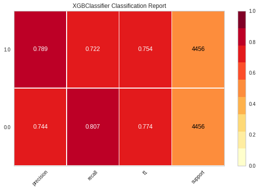

```python
from yellowbrick.classifier import ClassificationReport



clf = XGBClassifier()
visualizer = ClassificationReport(clf,support=True)

visualizer.fit(X_train_scaled, y_train_os)        # Fit the visualizer and the model
visualizer.score(X_test_scaled, y_test_os)        # Evaluate the model on the test data
visualizer.show()
```

**2. Confusion matrix**

This takes values and returns a report showing how each of the test values predicted classes compare to their actual classes. Data scientists use confusion matrices to understand which classes are most easily confused

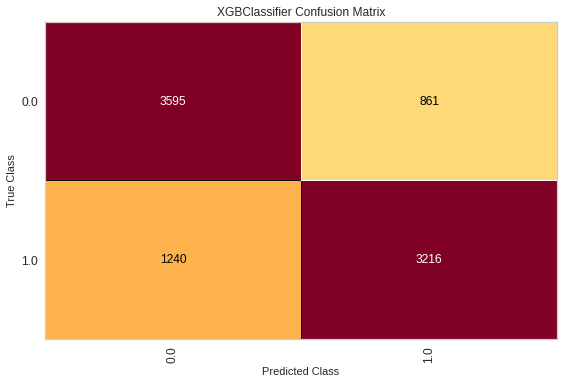

```python
from yellowbrick.classifier import ConfusionMatrix

cm = ConfusionMatrix(clf)

# Fit fits the passed model. This is unnecessary if you pass the visualizer a pre-fitted model
cm.fit(X_train_scaled, y_train_os)

# To create the ConfusionMatrix, we need some test data. Score runs predict() on the data
# and then creates the confusion_matrix from scikit-learn.
cm.score(X_test_scaled, y_test_os)

# How did we do?
cm.show()
```

**3. ROC/AUC curve**

The Receiver Operating Characteristic [(ROC)](https://www.scikit-yb.org/en/latest/api/classifier/rocauc.html) is a measure of a classifier’s predictive quality that compares and visualizes the tradeoff between the model’s sensitivity and specificity. When plotted, a ROC curve displays the true positive rate on the Y axis and the false positive rate on the X axis on both a global average and per-class basis.

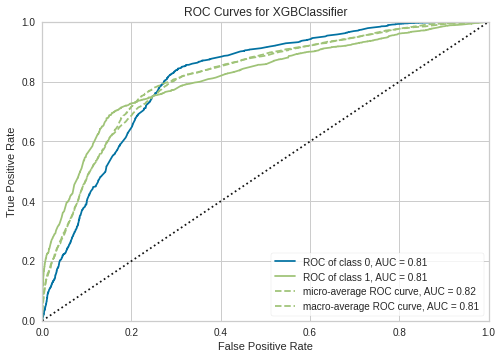

```python
from yellowbrick.classifier import ROCAUC

visualizer = ROCAUC(clf, classes=["0", "1"])

visualizer.fit(X_train_scaled, y_train_os)        # Fit the training data to the visualizer
visualizer.score(X_test_scaled, y_test_os)        # Evaluate the model on the test data
visualizer.show()
```

**4. Precision Recall curves**

The PrecisionRecallCurve [(PRC)](https://www.scikit-yb.org/en/latest/api/classifier/prcurve.html) shows the tradeoff between a classifier’s precision, a measure of result relevancy, and recall, a measure of completeness. For each class, precision is defined as the ratio of true positives to the sum of true and false positives, and recall is the ratio of true positives to the sum of true positives and false negatives.

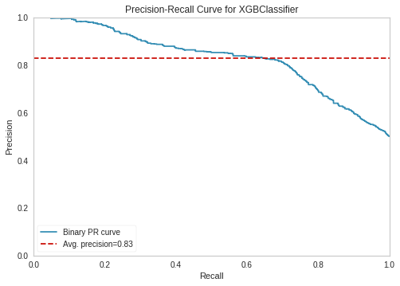

```python
from xgboost import XGBClassifier
from yellowbrick.classifier import PrecisionRecallCurve

# Create the visualizer, fit, score, and show it
viz = PrecisionRecallCurve(XGBClassifier(random_state=0), per_class=True,
    cmap="Set1")
viz.fit(X_train_scaled, y_train_os)
viz.score(X_test_scaled, y_test_os)
viz.show()
```

**5. Class Prediction Error**

Like the Classification Report, Class Prediction Error [(CPE)](https://www.scikit-yb.org/en/latest/api/classifier/class_prediction_error.html) plot shows the support (number of training samples) for each class in the fitted classification model as a stacked bar chart. Each bar is segmented to show the proportion of predictions (including false negatives and false positives, like a Confusion Matrix) for each class

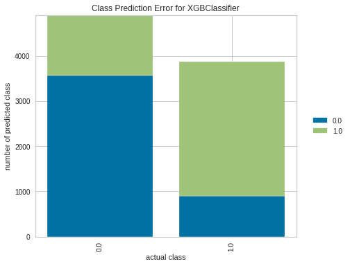

```python
from yellowbrick.classifier import ClassPredictionError


visualizer = ClassPredictionError(
    XGBClassifier(random_state=42, n_estimators=10)
)

# Fit the training data to the visualizer
visualizer.fit(X_train_scaled, y_train_os)

# Evaluate the model on the test data
visualizer.score(X_test_scaled, y_test_os)

# Draw visualization
visualizer.show()
```

# Deployment

[Deployment link](https://employee-leave-data-science.herokuapp.com/)

[The link to my github](https://github.com/valera2042/HR_analytics)

# Thank you for your attention!